# Chapter 8 - Statistical Computing

[figure not shown]

## Today

- Recap: **R (for programmers)**
- How did you manage with Chapter 8?
- What was difficult?
- How did you solve the exercises?

## Disclaimer

- **RStudio is not R!** (but maybe soon...)
- That is, you don't need RStudio to program and run R.
- But it will provide a fantastic integrated development environment (IDE)!

## R is a programming language

```r
for (i in -2:2) {
    if (i < 0 | i > 1) {
        a <- i
    } else {
        a <- pi
    }
    print(a)
}
```

```
[1] -2
[1] -1
[1] 3.141593
[1] 3.141593
[1] 2
```

```r
for(i in-2:2){if(i<0|i>1){a=i}else{a=pi};print(a)}
```

```
[1] -2
[1] -1
[1] 3.141593
[1] 3.141593
[1] 2
```

## R's own assignment operator

```r
x <- 42
```

```r
"the meaning of life, the universe, and everything" -> x
```

## Code is parsed line by line, blocks are within braces

This will work:

```
if () {
    ...
} else {
    ...
}
```

This will **stop with an error** after the first closing braces:

```
if () {
    ...
}
else {
    ...
}
```

However, this will work:

```
for (i in 1:10) {
    if () {
        ...
    }
    else {
        ...
    }
}
```

and also this:

```
{
    if () {
        ...
    }
    else {
       ...
    }
}
```

Bottom line: **Keep on cuddling! (even if you don't like it)**

## Indexing starts at 1 (not 0)

```r
y <- 5:7
```

```r
y
```

1. 5

2. 6

3. 7

```r
str(y)
```

```
 int [1:3] 5 6 7
```

```r
y[1]
```

5

## More on index and range

```r
(y <- 5:7)
```

1. 5

2. 6

3. 7

Compare with Python (v.3):

```
>>> y = list(range(5,7))
>>> y
[5, 6]
>>> y[0]
5
```

## Operators

`&` Logical "and"

`|` Logical "or"

`%%` Modulo (remainder of integer division)

**Compare with Python:** `&&`, `||`, `%`

Bonus operator: `%in%`

```r
3 %in% 1:5
```

TRUE

## "Everything is a function"

```r
mean
```

```
function (x, ...)
UseMethod("mean")
```

```r
"mean"
```

'mean'

```r
mean()
```

```
Error in mean.default(): argument "x" is missing, with no default
Traceback:

1. mean()
2. mean.default()
```

```r
mean <- 1:5
mean
```

1. 1

2. 2

3. 3

4. 4

5. 5

```r
mean(mean)
```

3

## Basic modes and data structures

### Modes

- **Numeric** (`1`, `3.141593`)
- **String** (`"apa"`)
- **Logical** (`TRUE`, `FALSE`)

### Data structures

- **Vector** (series of elements all of the same mode)
- **Matrix** ("vector in a tabular X-by-Y format")
- **Array** (N-dimensional matrix)
- **Dataframe** (Similar to matrix, but potentially with different modes)
- **List** (Can contain any type of data structures)

## Vector operations

```r
x <- c(1, 2, 3, 4)
```

```r
x + 10
```

1. 11

2. 12

3. 13

4. 14

### Compare with Python

```
>>> x = [1, 2, 3, 4]
>>> x + 10
Traceback (most recent call last):
  File "<stdin>", line 1, in <module>
TypeError: can only concatenate list (not "int") to list
```

### Use datatype in Python provided by NumPy

```
>>> import numpy as np
>>> x = np.array(x)
>>> x + 10
array([11, 12, 13, 14])
```

## Autocasting

```r
x <- c(1, 2, 3, "4")
```

```r
x + 10
```

```
Error in x + 10: non-numeric argument to binary operator
Traceback:
```

```r
mode(x)
```

'character'

```r
as.numeric(x) + 10
```

1. 11

2. 12

3. 13

4. 14

## Indexing and slicing

Vector

```r
x <- c(1:4, 3:1)
```

```r
x
```

1. 1

2. 2

3. 3

4. 4

5. 3

6. 2

7. 1

```r
x[5]
```

3

```r
x[x != 4]
```

1. 1

2. 2

3. 3

4. 3

5. 2

6. 1

```r
x[x != 4][5]
```

2

```r
x
```

1. 1

2. 2

3. 3

4. 4

5. 3

6. 2

7. 1

```r
x[c(1, 4)] <- 10
```

```r
x
```

1. 10

2. 2

3. 3

4. 10

5. 3

6. 2

7. 1

## Indexing and slicing

Matrix

```r
m <- matrix(data = 1:9, nrow = 3, ncol = 3, byrow = FALSE )
```

```r
m <- matrix(1:9, 3, 3)
```

```r
m
```

A matrix: 3 × 3 of type int

| 1 | 4 | 7 |
| --- | --- | --- |
| 2 | 5 | 8 |
| 3 | 6 | 9 |

```
1 4 7
2 5 8
3 6 9
```

```r
m[1, ]
```

1. 1

2. 4

3. 7

```r
m[, 1]
```

1. 1

2. 2

3. 3

```
1 4 7
2 5 8
3 6 9
```

```r
m[1, 2]
```

4

```r
m[1, ][2]
```

4

```r
m[4]
```

4

## Indexing and slicing

Dataframe

```r
anscombe # A build-in example data set stored as a dataframe
```

A data.frame: 11 × 8

| x1 <dbl> | x2 <dbl> | x3 <dbl> | x4 <dbl> | y1 <dbl> | y2 <dbl> | y3 <dbl> | y4 <dbl> |
| --- | --- | --- | --- | --- | --- | --- | --- |
| 10 | 10 | 10 | 8 | 8.04 | 9.14 | 7.46 | 6.58 |
| 8 | 8 | 8 | 8 | 6.95 | 8.14 | 6.77 | 5.76 |
| 13 | 13 | 13 | 8 | 7.58 | 8.74 | 12.74 | 7.71 |
| 9 | 9 | 9 | 8 | 8.81 | 8.77 | 7.11 | 8.84 |
| 11 | 11 | 11 | 8 | 8.33 | 9.26 | 7.81 | 8.47 |
| 14 | 14 | 14 | 8 | 9.96 | 8.10 | 8.84 | 7.04 |
| 6 | 6 | 6 | 8 | 7.24 | 6.13 | 6.08 | 5.25 |
| 4 | 4 | 4 | 19 | 4.26 | 3.10 | 5.39 | 12.50 |
| 12 | 12 | 12 | 8 | 10.84 | 9.13 | 8.15 | 5.56 |
| 7 | 7 | 7 | 8 | 4.82 | 7.26 | 6.42 | 7.91 |
| 5 | 5 | 5 | 8 | 5.68 | 4.74 | 5.73 | 6.89 |

```r
anscombe[[1]]
```

1. 10

2. 8

3. 13

4. 9

5. 11

6. 14

7. 6

8. 4

9. 12

10. 7

11. 5

```r
colnames(anscombe)
```

1. 'x1'

2. 'x2'

3. 'x3'

4. 'x4'

5. 'y1'

6. 'y2'

7. 'y3'

8. 'y4'

```r
anscombe$x1
```

1. 10

2. 8

3. 13

4. 9

5. 11

6. 14

7. 6

8. 4

9. 12

10. 7

11. 5

```r
anscombe[[1]]
```

1. 10

2. 8

3. 13

4. 9

5. 11

6. 14

7. 6

8. 4

9. 12

10. 7

11. 5

```r
anscombe[1]
```

A data.frame: 11 × 1

| x1 <dbl> |
| --- |
| 10 |
| 8 |
| 13 |
| 9 |
| 11 |
| 14 |
| 6 |
| 4 |
| 12 |
| 7 |
| 5 |

```r
class(anscombe[1])
```

'data.frame'

```r
class(anscombe[[1]])
```

'numeric'

```r
is.vector(anscombe[[1]])
```

TRUE

```r
anscombe[[1]][1]
```

10

```r
# First row in the dataframe
anscombe[1, ]
```

A data.frame: 1 × 8

|  | x1 <dbl> | x2 <dbl> | x3 <dbl> | x4 <dbl> | y1 <dbl> | y2 <dbl> | y3 <dbl> | y4 <dbl> |
| --- | --- | --- | --- | --- | --- | --- | --- | --- |
| 1 | 10 | 10 | 10 | 8 | 8.04 | 9.14 | 7.46 | 6.58 |

## Apply-like functions

R's (faster) alternative to `for` loops

**Note**: Syntax may be tricky. Practice!

```r
# Example in CSB p. 280-283
#
# Prepare some data
DNAlist <- list(A = "GTTTCG", B = "GCCGCA",
                C = "TTATAG", D = "CGACGA")
```

```r
# Write a function that counts nucleotides
count_nucl <- function(seq, nucl) {
    pos <- gregexpr(pattern = nucl, text = seq)[[1]]
    if (pos[1] == "-1") {
        return(0)
    } else {
        return(length(pos))
    }
}
```

Here they use the `sapply` function, "Apply a Function over a List or Vector":

```
sapply(x, FUN, ...)
```

`x` is a list, `FUN` the function, and ellipsis (`...`) are any arguments to `FUN`.

In the example, `x` is `DNAlist`, and `FUN` is `count_nucl`.

```r
print(sapply(DNAlist, count_nucl, nucl = "A"))
```

```
A B C D
0 1 2 2
```

```r
print(sapply(DNAlist, count_nucl, nucl = "C"))
```

```
A B C D
1 3 0 2
```

## Read data

- **Tip**: Prepare your data outside R as CSV (comma-, or tab-separated values file)
- **Tip 2**: Practice on using `read.table()`, and check returned data object carefully!
- **Tip 3**: Not comfortable with factors? Use `stringsAsFactors = FALSE` when importing.

## User functions

```r
"getRandDNA" <- function(n=20, probs=c(1,1,1,1)/4,
                         verbose = TRUE)
{
    # Get random DNA sequence
    # By: Johan Nylander
    # Last modified: 2009-10-06
    # Usage: getRandDNA(10, c(0.25,0.25,0.25,0.25))
    if (verbose)
        print(probs)
    dna <- sample(c("A","C","G","T"),
                  replace=TRUE, n, prob=probs)
    paste(dna, collapse="")
}
```

```r
getRandDNA()
```

```
[1] 0.25 0.25 0.25 0.25
```

'GGGGGAGGCTACGGGCAGGC'

```r
getRandDNA(40, verbose = FALSE)
```

'AGACCCACAAAGCCGGGCGCTTGTCCAGATGCAGGAAGAA'

## Basic statistics - know your data!

**Copy and save** the list of commands for doing summary statistics on CSB p. 288-289!

- `summary()`
- `range()`
- `by()`
- `cor()`
- `pairs()`
- `subset()`
- `rank()`
- `which.max()`, `which.min()`

```r
summary(iris)
```

```
  Sepal.Length    Sepal.Width     Petal.Length    Petal.Width
 Min.   :4.300   Min.   :2.000   Min.   :1.000   Min.   :0.100
 1st Qu.:5.100   1st Qu.:2.800   1st Qu.:1.600   1st Qu.:0.300
 Median :5.800   Median :3.000   Median :4.350   Median :1.300
 Mean   :5.843   Mean   :3.057   Mean   :3.758   Mean   :1.199
 3rd Qu.:6.400   3rd Qu.:3.300   3rd Qu.:5.100   3rd Qu.:1.800
 Max.   :7.900   Max.   :4.400   Max.   :6.900   Max.   :2.500
       Species
 setosa    :50
 versicolor:50
 virginica :50
```

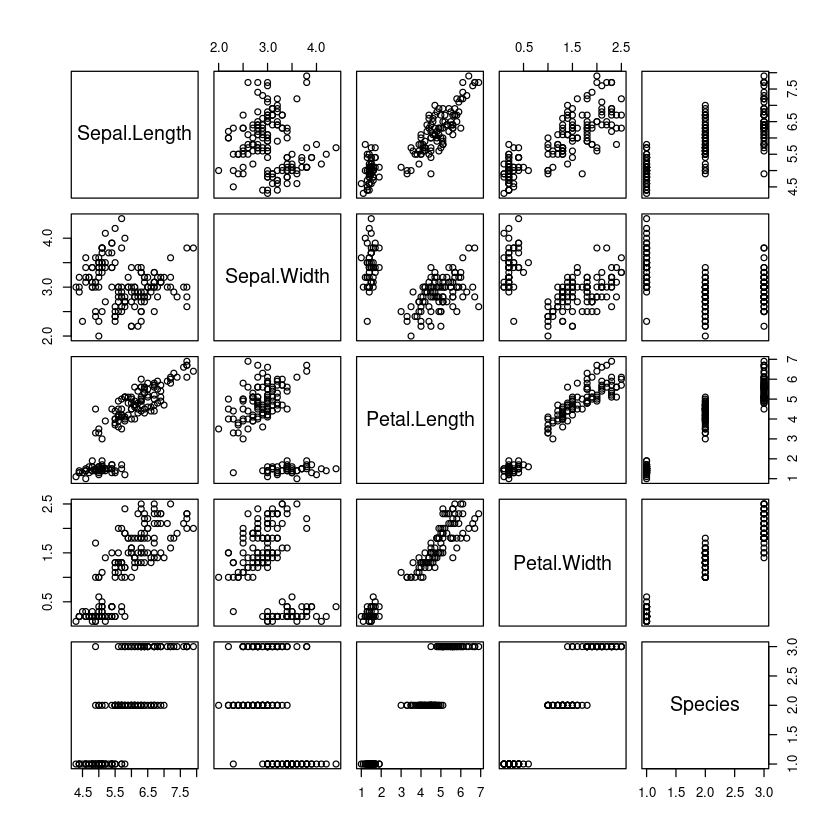

```r
pairs(iris)
```

## User-provided packages: The power of R!

```r
library(ape)
```

```r
help(package = "ape")
```

```r
?AAbin # Check the 'value' entry in the help text!
```

```r
data(woodmouse)
```

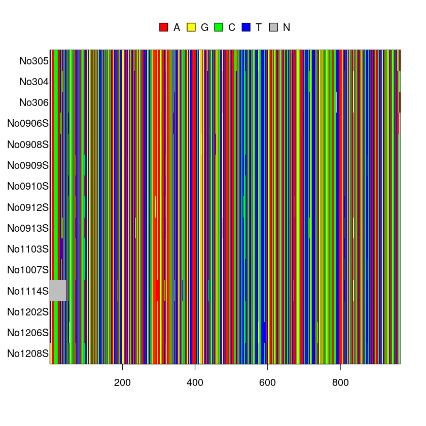

```r
image(woodmouse)
```

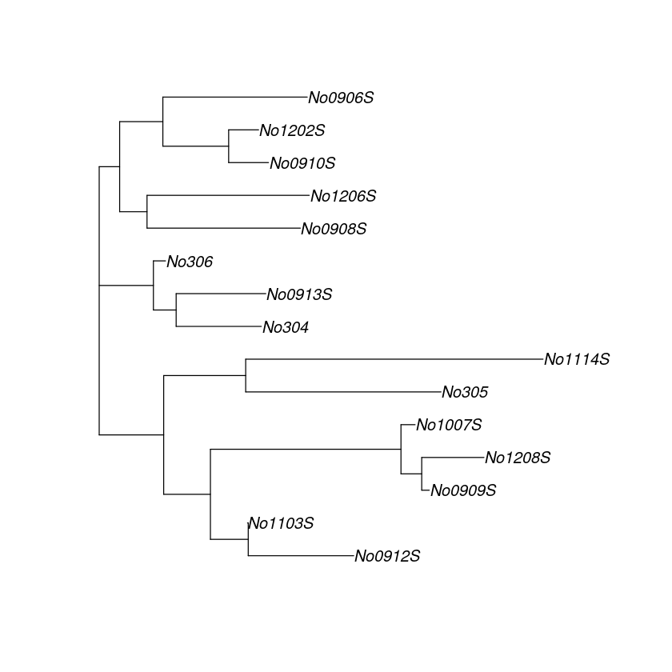

```r
plot(nj(dist.dna(woodmouse, "J")))
```

## Readability helps with reproducibility!

Compare

```
plot(nj(dist.dna(woodmouse, "J")))
```

with

```
mydata <- woodmouse

mymodel <- "JC69"

distmatrix <- dist.dna(mydata, model = mymodel)

tree <- nj(distmatrix)

plot(tree)
```

## Scripts

Good advice in CSB, p. 285-287.

In addition:

**Include an "R-shebang" in your script as the first line:**

`#!/usr/bin/env Rscript`

Allows you to run your script as any other command-line program:

```
$ my_r_script
```

Remember to set permissions and place your script in your `$PATH`:

```
$ chmod +x my_r_script.R
$ cp my_r_script.R ~/bin/my_r_script
```

**Parsing user arguments are tricky!**

[figure not shown]

**Use a (pure) R-package instead!**

Example packages (on [CRAN](https://cran.r-project.org/)): getopt, optparse, docopt, argparser

**Don't "help" users by installing packages from within your scripts!**

```
if (!requireNamespace("SomePackage", quietly = TRUE)) {
    install.packages("SomePackage")
}
```

**Instead**: Provide documentation, both inside and outside your code, for the installation!

## R-markdown

**Maximize reproducibility: Code and comments in the same place!**

**Easy to share in different formats (code, PDF, html, MS Word, ...)**

````
---
output: pdf_document
---

# R-markdown example

- Last modified: ons feb 10, 2021  05:50
- Sign: JN

## Description

Here is an image of the data

```{r, echo = FALSE}
library("ape")
data(woodmouse)
image(woodmouse)
```
---

Here are both the command and the tree

```{r}
plot(nj(dist.dna(woodmouse, "J")))
```

We can also use, e.g., `{r, include = FALSE}`,
to run the code, but not include the output
from the command in the PDF.

This is the R-code we used (which is not going
to be executed again, only displayed with
syntax highlighting in the PDF):

```r
library("ape")
data(woodmouse)
image(woodmouse)
plot(nj(dist.dna(woodmouse, "J")))
```

See more here:
[Link to the R-markdown Reference Guide](https://rstudio.com/wp-content/uploads/2015/03/rmarkdown-reference.pdf)
````

You can render ("compile") the `.Rmd` files in RStudio, but also directly from R (requires package `rmarkdown`):

```
rmarkdown::render("ape.Rmd")
rmarkdown::render("ape.Rmd", output_format="word_document")
```

**Note:** You may accomplish a similar workflow (documentation and code in the same document) by using Jupyter notebooks with the R kernel.

## Exercises

## Assignment for next occasion (Feb 25)

- Chapter 9. Data Wrangling and Visualization (R)
- **Use the Slack channels (https://bioinfo-course-2020.slack.com)!**